# Extra plots

Maarten van der Velde

Last updated: 2024-04-08

# Overview

This notebook contains extra plots for in the paper.

# Setup

```r
library(fst)
library(data.table)
library(tidyr)
library(purrr)
library(furrr)
library(stringr)
library(ggplot2)
library(patchwork)
library(wesanderson)
```

```r
source(file.path("..", "scripts", "99_slimstampen_model_funs.R"))
```

```r
future::plan("multisession", workers = 9) # Set to desired number of cores
```

```r
theme_set(theme_light(base_size = 14) +
            theme(strip.text = element_text(colour = "black")))

condition_colours <- wes_palette("Darjeeling1", n = 5)
condition_colours[c(2, 4, 5)] <- condition_colours[c(4, 5, 2)]

dataset_colours <- wes_palette("Darjeeling2", n = 5)[c(2, 3)]
```

# Could we estimate SoF from a single RT

We always require at least 3 responses before we start adjusting SoF from its starting point of 0.3. However, we could also start adjusting after the first response, based on the RT of that trial.

What does the distribution of RTs look like?

Load the data:

```r
d_gl <- read_fst(file.path("..", "data", "formatted_Grandes_Lignes.fst"))
```

```
fstcore package v0.9.14
(OpenMP was not detected, using single threaded mode)
```

```r
# d_ss <- read_fst(file.path("..", "data", "formatted_Stepping_Stones.fst"))
# d <- rbind(d_gl, d_ss)
# rm(d_gl, d_ss)
```

Add a trial counter:

```r
setDT(d_gl)
setorder(d_gl, user_id, fact_id, start_time)
d_gl[, trial := 1:.N, by = .(user_id, fact_id)]
```

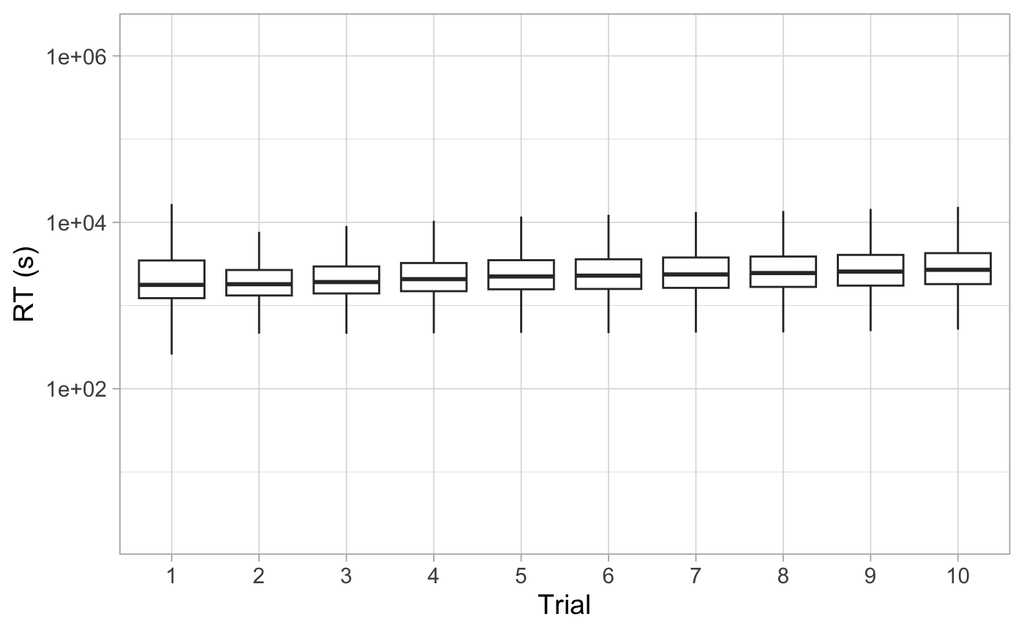

```r
d_gl_first10 <- d_gl[trial <= 10 & correct == 1]

ggplot(d_gl_first10[sample(1e6)], aes(x = as.factor(trial), y = rt)) +
  geom_boxplot(outlier.shape = NA) +
  labs(x = "Trial", y = "RT (s)") +
  scale_y_log10()
```

Plot the quantiles of the response time distribution by trial:

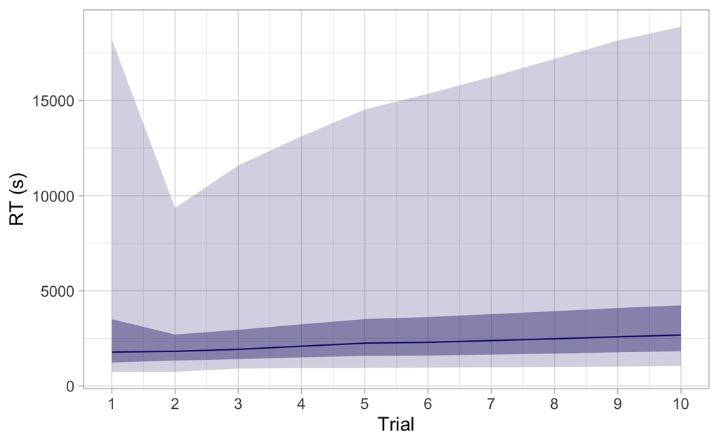

```r
rt_quantiles <- d_gl_first10[, .(quantile =  c(0.025, 0.25, 0.5, 0.75, 0.975),
                                rt = quantile(rt, probs = c(0.025, 0.25, 0.5, 0.75, 0.975))), by = trial]

rt_quantiles_wide <- dcast(rt_quantiles, trial ~ quantile, value.var = "rt")

ggplot(rt_quantiles_wide, aes(x = trial)) +
  geom_ribbon(aes(ymin = `0.025`, ymax = `0.975`), fill = "midnightblue", alpha = 0.2) +
  geom_ribbon(aes(ymin = `0.25`, ymax = `0.75`), fill = "midnightblue", alpha = 0.4) +
  geom_line(aes(y = `0.5`),  colour = "midnightblue") +
  scale_x_continuous(breaks = 1:10) +
  labs(x = "Trial", y = "RT (s)")
```

Let’s zoom in on the third trial, which is the first delayed repetition (and also the data we present elsewhere in the paper).

```r
rt_quantiles_wide[trial == 3]
```

| trial | 0.025 | 0.25 | 0.5 | 0.75 | 0.975 |
| --- | --- | --- | --- | --- | --- |
| 3 | 914 | 1410 | 1924 | 2953 | 11594 |

# Difference in SoF translated to retention period

Memory functions:

```r
activation <- function (t, alpha) {
  log(t^-alpha)
}

p_recall <- function(a, tau, s = .2) {
  1 / (1 + exp(-(a - tau)/s))
}
```

Given a retrieval threshold, we can calculate the time until activation drops below this threshold.

```r
time_until_threshold <- function (tau, alpha) {
  exp(-tau/alpha)
}
```

```r
time_until_threshold(-0.8, 0.5)
```

```
[1] 4.953032
```

```r
t <- seq(1, 60*60, .1)

d_sof_sim <- data.table(sof = rep(c(0.2, 0.25, 0.3, 0.35, 0.4), each = length(t)),
                        t = rep(t, 5))

d_sof_sim[, activation := activation(t, sof)]
d_sof_sim[, p_recall := p_recall(activation, -.8, s = .2)]
d_sof_sim[, sof := as.factor(sof)]
levels(d_sof_sim$sof) <- c(expression(paste(alpha, " = 0.20")), expression(paste(alpha, " = 0.25")), expression(paste(alpha, " = 0.30")), expression(paste(alpha, " = 0.35")), expression(paste(alpha, " = 0.40")))
```

When does p(recall) drop below 5%?

```r
below_5pct <- d_sof_sim[p_recall < 0.05, .(t = min(t)), by = .(sof)]

convert_seconds_to_minutes_and_seconds <- function (time_in_seconds) {
  minutes <- floor(time_in_seconds / 60)
  seconds <- floor(time_in_seconds %% 60)
  sprintf("%dm%ds", minutes, seconds)
}

below_5pct[, t_label := convert_seconds_to_minutes_and_seconds(t)]
below_5pct
```

| sof | t | t_label |
| --- | --- | --- |
| paste(alpha, " = 0.20") | 1037.4 | 17m17s |
| paste(alpha, " = 0.25") | 258.7 | 4m18s |
| paste(alpha, " = 0.30") | 102.5 | 1m42s |
| paste(alpha, " = 0.35") | 52.9 | 0m52s |
| paste(alpha, " = 0.40") | 32.3 | 0m32s |

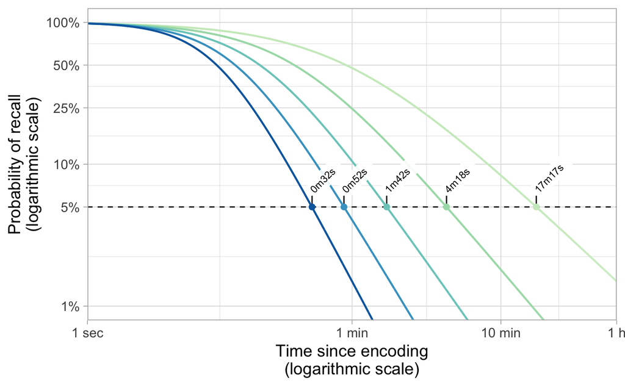

```r
p_p_recall <- ggplot(d_sof_sim, aes(x = t, y = p_recall, colour = sof)) +
  # Add y intercept lines for p = 5%
  geom_hline(yintercept = 0.05, linetype = 2) +
  geom_line(lwd = .8) +
  geom_segment(data = below_5pct, aes(x = t, xend = t, y = 0.05, yend = 0.06), colour = "black") +
  geom_point(data = below_5pct, aes(x = t, y = 0.05), size = 2) +
  ggtext::geom_richtext(data = below_5pct,
                        aes(x = t, y = .065, label = t_label),
                        angle = 45,
                        hjust = 0,
                        vjust = .5,
                        label.size = NA,
                        colour = "NA",
                        alpha = .9,
                        size = 3) +
  geom_text(data = below_5pct,
            aes(x = t, y = .065, label = t_label),
            angle = 45,
            hjust = 0,
            vjust = .5,
            colour = "black",
            size = 3) +
    scale_x_log10(breaks = c(1, 60, 10*60, 60*60),
                labels = c("1 sec", "1 min", "10 min", "1 h"),
                expand = c(0, 0)) +
  scale_y_log10(breaks = c(1, 0.5, .25, .1, 0.05, 0.01), labels = scales::percent_format(accuracy = 1)) +
  scale_colour_manual(values = RColorBrewer::brewer.pal(name = "GnBu", n = 6)[2:6], labels = scales::label_parse()) +
  guides(colour = "none") +
  labs(x = "Time since encoding\n(logarithmic scale)", y = "Probability of recall\n(logarithmic scale)", colour = "Speed of Forgetting") +
  coord_cartesian(ylim = c(.01, 1), xlim = c(1, 60*60))


p_p_recall
```

# Reaction time is noisy

I want to plot the final alpha estimate for each learning sequence against the RT in the third trial of the learning sequence.

```r
d_alpha_gl <- read_fst(file.path("..", "data", "training_Grandes_Lignes.fst"))
d_alpha_ss <- read_fst(file.path("..", "data", "training_Stepping_Stones.fst"))
setDT(d_alpha_gl)
setDT(d_alpha_ss)
d_alpha <- rbind(d_alpha_gl, d_alpha_ss)
rm(d_alpha_gl, d_alpha_ss)
```

Also load the raw learning sequence data to get the RT in the third trial.

```r
d_learn_gl <- read_fst(file.path("..", "data", "formatted_Grandes_Lignes.fst"))
d_learn_ss <- read_fst(file.path("..", "data", "formatted_Stepping_Stones.fst"))
setDT(d_learn_gl)
setDT(d_learn_ss)
d_learn <- rbind(d_learn_gl, d_learn_ss)
rm(d_learn_gl, d_learn_ss)
setorder(d_learn, user_id, fact_id, start_time)
```

Keep the first three trials of each learning sequence.

```r
d_learn[, trial := 1:.N, by = .(user_id, fact_id)]
d_learn <- d_learn[trial <= 3]
```

Merge with alpha calculations:

```r
d_alpha <- d_learn[d_alpha, on = .(user_id, fact_id)]
d_alpha <- d_alpha[!is.na(start_time)] # Remove sequences that are not in the training set
```

Round alpha to the nearest .05

```r
round_to_nearest_0.05 <- function(x) {
  round(x * 20) / 20
}

d_alpha[, alpha_rnd := round_to_nearest_0.05(alpha)]
```

For easy interpretability of the plot, keep only correct responses, with 0 < RT < 60s, and 0.2 < alpha_rnd < 0.4.

```r
d_alpha_clean <- d_alpha[correct == TRUE & rt > 0 & rt < 60*1000 & alpha_rnd >= 0.2 & alpha_rnd <= 0.4]
d_alpha_clean[, alpha_rnd := as.factor(alpha_rnd)]
levels(d_alpha_clean$alpha_rnd) <- c(expression(paste(alpha, " = 0.2")), expression(paste(alpha, " = 0.25")), expression(paste(alpha, " = 0.3")), expression(paste(alpha, " = 0.35")), expression(paste(alpha, " = 0.4")))
```

```r
d_alpha_clean_median <- d_alpha_clean[, .(rt = median(rt)), by = .(user_id, trial, alpha_rnd)]
```

Plot RT against alpha in each trial:

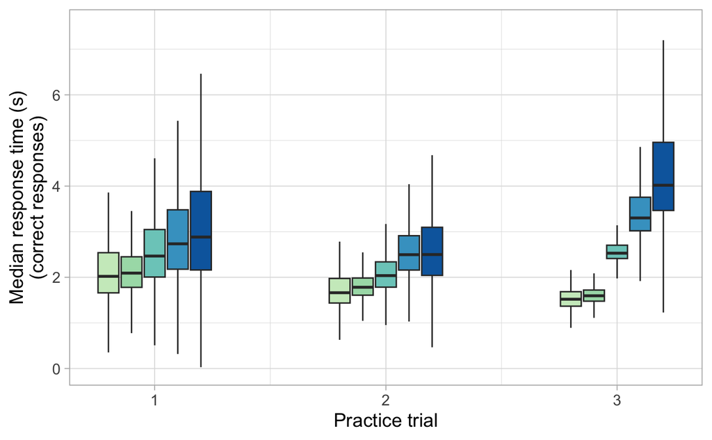

```r
p_rt_by_alpha <- ggplot(d_alpha_clean_median, aes(group = interaction(trial, alpha_rnd), x = trial, y = rt/1000)) +
  geom_boxplot(aes(fill = alpha_rnd), width = .5, outlier.shape = NA) +
  scale_fill_manual(values = RColorBrewer::brewer.pal(name = "GnBu", n = 6)[2:6], labels = scales::label_parse()) +
  scale_x_continuous(breaks = 1:3) +
  scale_y_continuous() +
  guides(fill = "none") +
  labs(x = "Practice trial", y = "Median response time (s)\n(correct responses)", colour = "Speed of Forgetting") +
  coord_cartesian(ylim = c(0, 7.5))

p_rt_by_alpha
```

Calculate the correlation between alpha and RT per trial on a sample of the data:

```r
d_alpha_clean[sample(.N, 1e6)][, .(spearman_rho = cor(rt, alpha, method = "spearman")), by = trial]
```

| trial | spearman_rho |
| --- | --- |
| 1 | 0.2063647 |
| 2 | 0.2482578 |
| 3 | 0.7326251 |

We can make a similar plot for accuracy.

```r
d_alpha_acc <- d_alpha[rt > 0 & rt < 60*1000 & alpha_rnd >= 0.2 & alpha_rnd <= 0.4]
d_alpha_acc[, alpha_rnd := as.factor(alpha_rnd)]
levels(d_alpha_acc$alpha_rnd) <- c(expression(paste(alpha, " = 0.20")), expression(paste(alpha, " = 0.25")), expression(paste(alpha, " = 0.30")), expression(paste(alpha, " = 0.35")), expression(paste(alpha, " = 0.40")))
```

```r
d_alpha_acc_mean <- d_alpha_acc[, .(accuracy = mean(correct),
                                    accuracy_se = sd(correct)/sqrt(.N)), by = .(user_id, trial, alpha_rnd)]
```

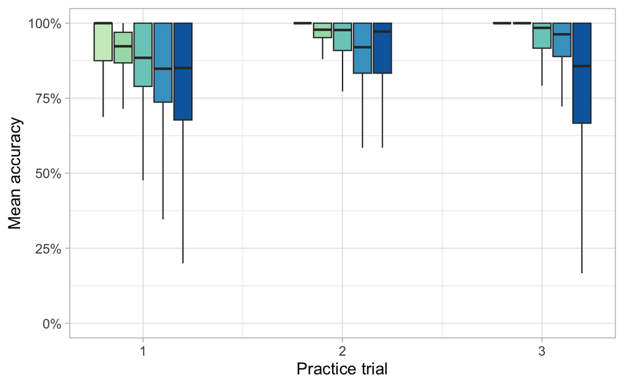

```r
p_acc_by_alpha <- ggplot(d_alpha_acc_mean, aes(group = interaction(trial, alpha_rnd), x = trial, y = accuracy)) +
  geom_boxplot(aes(fill = alpha_rnd), width = .5, outlier.shape = NA) +
  scale_fill_manual(values = RColorBrewer::brewer.pal(name = "GnBu", n = 6)[2:6], labels = scales::label_parse()) +
  scale_x_continuous(breaks = 1:3) +
  scale_y_continuous(labels = scales::percent_format()) +
  guides(fill = "none") +
  labs(x = "Practice trial", y = "Mean accuracy", colour = "Speed of Forgetting") +
  coord_cartesian(ylim = c(0, 1))

p_acc_by_alpha
```

# Plot activation and probability of recall in learning session

```r
t <- seq(0, 85000, by = 50)
alpha <- c(0.2, .25, 0.3, .35, 0.4)
act <- list()
r <- data.table()
encounter_times <- c(0, 14400, 78850)


for(j in seq_along(alpha)) {
  a <- alpha[j]
  fact_id <- paste0("fact", a)
  for (i in seq_along(t)) {
    activation <- calculate_activation(time = t[i], id = fact_id, factalpha = a, responses = r)
    activation_proj <- calculate_activation(time = t[i] + 15000, id = fact_id, factalpha = a, responses = r)
    p_r <- p_recall(activation, tau = -0.8)
    # if (activation_proj <= -0.8) {
    if (t[i] %in% encounter_times) {
        r <- rbind(r, list(fact_id = fact_id, text = "question", start_time = t[i], rt = 4000, correct = TRUE, threshold = -0.8))
    }
    act[[length(t)*(j-1) + i]] <- list(time = t[i], fact_id = fact_id, alpha = a, activation = activation, p_recall = p_r)
  }
}

act <- rbindlist(act)
r$alpha <- as.factor(stringr::str_remove(r$fact_id, "fact"))
act$alpha <- as.factor(act$alpha)
# reorder the levels of the alpha factor to 0.2, 0.4, 0.3
levels(act$alpha) <- c(expression(paste(alpha, " = 0.20")), expression(paste(alpha, " = 0.25")), expression(paste(alpha, " = 0.30")), expression(paste(alpha, " = 0.35")), expression(paste(alpha, " = 0.40")))
levels(r$alpha) <- c(expression(paste(alpha, " = 0.20")), expression(paste(alpha, " = 0.25")), expression(paste(alpha, " = 0.30")), expression(paste(alpha, " = 0.35")), expression(paste(alpha, " = 0.40")))




p_act <- ggplot(act, aes(x = time/1000, y = activation, colour = alpha, group = alpha)) +
  geom_hline(yintercept = -.8, linetype = 2) +
  geom_line(lwd = .8) +
  geom_vline(data = NULL, xintercept = encounter_times/1000, lwd = 1.25, colour = "black") +
  geom_point(data = act[time %in% encounter_times & time > 0], aes(x = time/1000, y = activation), size = 2) +
  scale_colour_manual(values = RColorBrewer::brewer.pal(name = "GnBu", n = 6)[2:6], labels = scales::label_parse()) +
  guides(colour = guide_legend(override.aes = list(shape = 15, size = 6, lwd = 0))) +
  labs(x = "Time (s)",
       y = "Activation",
       colour = "Speed of Forgetting")



p_p_rec <- ggplot(act, aes(x = time/1000, y = p_recall, colour = alpha, group = alpha)) +
  geom_hline(yintercept = .5, linetype = 2) +
  geom_line(lwd = .8) +
  geom_vline(data = NULL, xintercept = encounter_times/1000, lwd = 1.25, colour = "black") +
  geom_point(data = act[time %in% encounter_times & time > 0], aes(x = time/1000, y = p_recall), size = 2) +
  # Add labels for p_recall at encounter times, formatted as "50%"
  geom_label(data = act[time %in% encounter_times & time > 0], aes(x = time/1000, y = p_recall, label = scales::percent(p_recall, 1)), size = 4, hjust = -.15, vjust = .5, colour = "black", label.size = NA, label.padding = unit(0.2, "lines"), alpha = .9) +

  scale_y_continuous(labels = scales::percent_format()) +
  scale_colour_manual(values = RColorBrewer::brewer.pal(name = "GnBu", n = 6)[2:6], labels = scales::label_parse()) +
  # Make colour legend a rectangle and remove the line in the guide
  guides(colour = guide_legend(override.aes = list(shape = 15, size = 6, lwd = 0))) +
  labs(x = "Time (s)",
       y = "Probability of recall",
       colour = "Speed of Forgetting")
```

# Combine plots

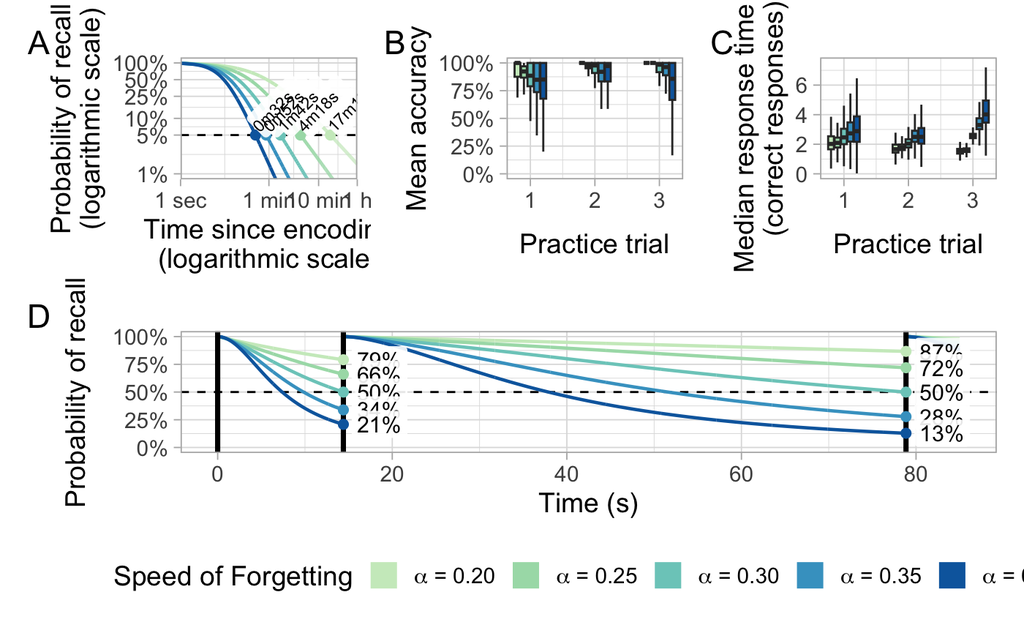

```r
(p_p_recall + p_acc_by_alpha + p_rt_by_alpha) / p_p_rec +
  plot_layout(guides = "collect") +
  plot_annotation(tag_levels = "A") &
  theme(legend.position = "bottom")

ggsave(file.path("..", "output", "Fig0.png"), device = "png", width = 10, height = 8)
```